# R markdown template

Adam Finnemann

September 24, 2017

Aim: get an complete overview of the specific sections (onames) for LoN workers that worked in sections (as fname).

Section workers is found by searching for “Section” in fname. Workers with fname = “Secretary of Section” are excluded.

```r
section_worker <- da %>%
  filter(str_detect(da$fname, "Section")) %>%
  filter(fname != "Secretary of Section")
section_worker %>%
  filter(!duplicated(id)) %>%
  nrow
```

```
## [1] 261
```

356 observations from 261 individuals are found

Their specific sections are found

```r
section_worker<-droplevels(section_worker)

sections <-summary(section_worker$oname)

sections <- sections %>% as.data.frame()
sections$oname <- rownames(sections)

sections
```

```
##                                                                                                         .
## Administrative and Minorities Section                                                                  15
## Bombay Office                                                                                           1
## Central Opium Board                                                                                     1
## Central Section                                                                                         3
## Communications and Transit Section                                                                     11
## Department I (Department of General Affairs)                                                            3
## Department II                                                                                           3
## Deputy Secretary-General's Office                                                                       4
## Disarmament Section                                                                                    15
## Distribution of Documents                                                                              13
## Economic and Financial Section                                                                         40
## Economic Relations Section                                                                              1
## Financial Section & Economic Intelligence Service                                                      17
## Health Section                                                                                         34
## Information Section                                                                                    49
## Intellectual Cooperation and International Bureaux Section                                             10
## Internal Administration                                                                                 3
## Internal Control                                                                                        1
## League of Nations                                                                                       3
## Legal Section                                                                                          30
## Liaison with China                                                                                      1
## London Office                                                                                           2
## Mandates Section                                                                                       11
## Minorities Section                                                                                      2
## Personnel Office                                                                                        3
## Political Section                                                                                      29
## Pool                                                                                                    2
## PrÃ©cis-Writing Department                                                                              7
## Printing & Publishing Department                                                                        2
## Refugee Section                                                                                         2
## Rome Office                                                                                             1
## Russian Refugees Section\n\n                                                                            1
## Scientific Research Division                                                                            1
## Secretary-General's Office                                                                              2
## Social Questions and Opium Traffic Section                                                             19
## Stenographic Services                                                                                   1
## Saar Plebiscite Commission                                                                              1
## Translation                                                                                             1
## Treasury                                                                                                3
```

[output cut: 35 more lines]

```
## Refugee Section                                                                                                                                                                               Refugee Section
## Rome Office                                                                                                                                                                                       Rome Office
## Russian Refugees Section\n\n                                                                                                                                                     Russian Refugees Section\n\n
## Scientific Research Division                                                                                                                                                     Scientific Research Division
## Secretary-General's Office                                                                                                                                                         Secretary-General's Office
## Social Questions and Opium Traffic Section                                                                                                                         Social Questions and Opium Traffic Section
## Stenographic Services                                                                                                                                                                   Stenographic Services
## Saar Plebiscite Commission                                                                                                                                                         Saar Plebiscite Commission
## Translation                                                                                                                                                                                       Translation
## Treasury                                                                                                                                                                                             Treasury
## Under-Secretary-General's Office                                                                                                                                             Under-Secretary-General's Office
## Under Secretaries-Generals' in charge of Political Section Office                                                                           Under Secretaries-Generals' in charge of Political Section Office
## Under Secretary-Generals' in charge International Bureaux and Intellectual-Co-operation Section Office Under Secretary-Generals' in charge International Bureaux and Intellectual-Co-operation Section Office
## Under Secretary-Generals' in charge of Internal Administration Office                                                                   Under Secretary-Generals' in charge of Internal Administration Office
## Unspecified                                                                                                                                                                                       Unspecified
```

Further employment analysis is carried out for the following sections: health, disarmament, mandates, legal, communications and transit, information, economic and financial section (which goes together with the economic relations section and the financial & economic intelligence service), intellectual cooperation and international bureaux section, minorities (which go together with Administrative and Minorities), the social questions and opium traffic, and the political section

```r
oname_correct <- section_worker %>%
  mutate(oname = str_replace_all(oname, "Financial Section & Economic Intelligence Service","Economic and Financial Section"),
        oname = str_replace_all(oname, "Economic Relations Section","Economic and Financial Section"),
        oname = str_replace_all(oname, "Minorities Section", "Administrative and Minorities Section")
         )
```

Workers belonging to large sections are extracted. “large section” is defined as sections with 10 or more contracts.

```r
large_section <- summary(section_worker$oname) %>%
  as.data.frame()
large_section = mutate(large_section,oname = rownames(large_section))

large_section <- filter(large_section, . >9)


large_section_worker <- section_worker %>%
  filter(oname %in% large_section$oname) %>%
  droplevels(large_section$oname)

summary(large_section_worker$oname)
```

```
##                      Administrative and Minorities Section
##                                                         15
##                         Communications and Transit Section
##                                                         11
##                                        Disarmament Section
##                                                         15
##                                  Distribution of Documents
##                                                         13
##                             Economic and Financial Section
##                                                         40
##          Financial Section & Economic Intelligence Service
##                                                         17
##                                             Health Section
##                                                         34
##                                        Information Section
##                                                         49
## Intellectual Cooperation and International Bureaux Section
##                                                         10
##                                              Legal Section
##                                                         30
##                                           Mandates Section
##                                                         11
##                                          Political Section
##                                                         29
##                 Social Questions and Opium Traffic Section
##                                                         19
```

293 contracts remain in the 13 largest sections.

First gender balance for large sections are found as a table and visualized

```r
large_section_worker$gender <- as.factor(large_section_worker$gender)

large_section_worker <- large_section_worker %>%
  mutate(gender = recode(gender,"0" = "male", "1"="female"))

large_section_worker %>%
group_by(oname, gender) %>%
  tally()
```

```
## # A tibble: 22 x 3
## # Groups:   oname [?]
##                                                oname gender     n
##                                               <fctr> <fctr> <int>
##  1             Administrative and Minorities Section   male    14
##  2             Administrative and Minorities Section female     1
##  3                Communications and Transit Section   male    10
##  4                Communications and Transit Section female     1
##  5                               Disarmament Section   male    15
##  6                         Distribution of Documents   male    11
##  7                         Distribution of Documents female     2
##  8                    Economic and Financial Section   male    39
##  9                    Economic and Financial Section female     1
## 10 Financial Section & Economic Intelligence Service   male    16
## # ... with 12 more rows
```

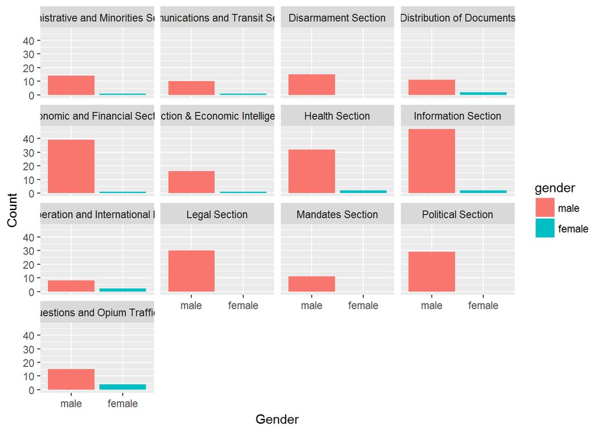

```r
large_section_worker %>%
   ggplot(aes(gender)) +
  geom_histogram(stat = "count", aes(fill = gender)) +
  scale_color_hue()+
  labs(x = "Gender", y = "Count")+
  facet_wrap(~oname)
```

Nationality distribution for the different sections are found:

```r
large_section_worker %>%
group_by(oname, nationality) %>%
  tally()
```

```
## # A tibble: 166 x 3
## # Groups:   oname [?]
##                                    oname   nationality     n
##                                   <fctr>        <fctr> <int>
##  1 Administrative and Minorities Section    Australian     1
##  2 Administrative and Minorities Section          Dane     2
##  3 Administrative and Minorities Section         Dutch     1
##  4 Administrative and Minorities Section        Finish     1
##  5 Administrative and Minorities Section         Greek     1
##  6 Administrative and Minorities Section        Indian     1
##  7 Administrative and Minorities Section         Irish     1
##  8 Administrative and Minorities Section Luxembourgish     1
##  9 Administrative and Minorities Section     Portugese     1
## 10 Administrative and Minorities Section       Spanish     1
## # ... with 156 more rows
```

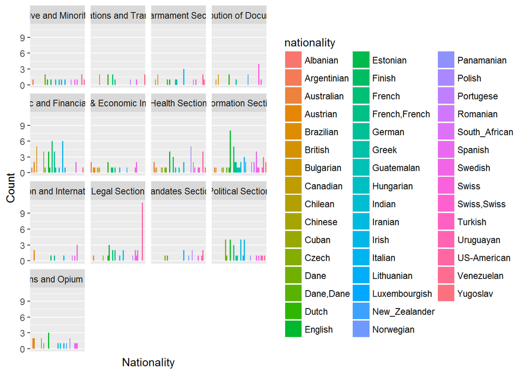

```r
large_section_worker %>%
   ggplot(aes(nationality)) +
  geom_histogram(stat = "count", aes(fill = nationality)) +
  scale_color_hue()+
  labs(x = "Nationality", y = "Count")+
  scale_x_discrete(breaks = NULL)+
  facet_wrap(~oname)
```

More specific nationality analysis?

Age analysis: calculating age at contract start and finding average

```r
large_section_worker <- large_section_worker %>%
  mutate(age_at_contract_start = begin_on_year - born_on_year)
sum(is.na(large_section_worker$age_at_contract_start))
```

```
## [1] 68
```

There are 68 missing data points for age

In percentage, how many of the contracts from each section are missing the age of the worker:

```r
large_section_worker %>%
  group_by(oname) %>%
  summarise(NAs = sum(is.na(age_at_contract_start)/length(age_at_contract_start)))
```

```
## # A tibble: 13 x 2
##                                                         oname        NAs
##                                                        <fctr>      <dbl>
##  1                      Administrative and Minorities Section 0.20000000
##  2                         Communications and Transit Section 0.09090909
##  3                                        Disarmament Section 0.20000000
##  4                                  Distribution of Documents 0.15384615
##  5                             Economic and Financial Section 0.37500000
##  6          Financial Section & Economic Intelligence Service 0.05882353
##  7                                             Health Section 0.17647059
##  8                                        Information Section 0.28571429
##  9 Intellectual Cooperation and International Bureaux Section 0.40000000
## 10                                              Legal Section 0.06666667
## 11                                           Mandates Section 0.18181818
## 12                                          Political Section 0.27586207
## 13                 Social Questions and Opium Traffic Section 0.36842105
```

What is the average age for of workers at their beggining of their contract:

```r
large_section_worker %>%
  group_by(oname) %>%
  summarise(mean_age = mean(age_at_contract_start, na.rm = T))
```

```
## # A tibble: 13 x 2
##                                                         oname mean_age
##                                                        <fctr>    <dbl>
##  1                      Administrative and Minorities Section 32.16667
##  2                         Communications and Transit Section 36.70000
##  3                                        Disarmament Section 34.50000
##  4                                  Distribution of Documents 35.81818
##  5                             Economic and Financial Section 34.68000
##  6          Financial Section & Economic Intelligence Service 31.50000
##  7                                             Health Section 36.00000
##  8                                        Information Section 35.82857
##  9 Intellectual Cooperation and International Bureaux Section 34.16667
## 10                                              Legal Section 36.46429
## 11                                           Mandates Section 34.44444
## 12                                          Political Section 38.52381
## 13                 Social Questions and Opium Traffic Section 34.00000
```

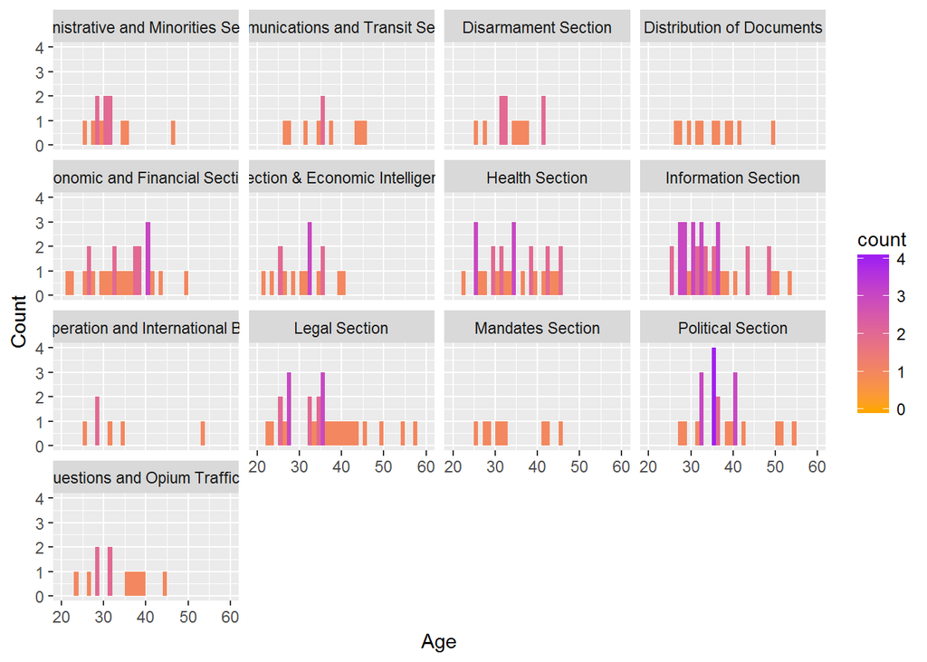

```r
large_section_worker %>%
   ggplot(aes(age_at_contract_start)) +

  geom_histogram(breaks = seq(20,60, 1), aes(fill = ..count..)) +
  scale_fill_gradient("count", low="orange", high="purple") +
  labs(x = "Age", y = "Count")+
  facet_wrap(~oname)
```

Employment graphs will be made. First a dataframe of contracts with missing data points is made.

```r
leftout_contracts <- large_section_worker %>%
  filter( is.na(large_section_worker$begin_date) | is.na(large_section_worker$end_date))

length(unique(leftout_contracts$pname))
```

```
## [1] 17
```

21 contract coming from 17 different people have missing data points and won’t be in the following analysis. The contract comes from the following sections.

```r
summary(droplevels(leftout_contracts$oname))
```

```
##         Communications and Transit Section
##                                          1
##                        Disarmament Section
##                                          2
##                  Distribution of Documents
##                                          1
##             Economic and Financial Section
##                                          3
##                        Information Section
##                                          4
##                              Legal Section
##                                          3
##                           Mandates Section
##                                          2
##                          Political Section
##                                          4
## Social Questions and Opium Traffic Section
##                                          1
```

The 21 left out contracts are:

```r
leftout_contracts %>% select(pname, oname, begin_date, end_date)
```

```
##                          pname                                      oname
## 1         Solon George Xenakis             Economic and Financial Section
## 2              Harold Nicolson                          Political Section
## 3              Julian Nogueira                           Mandates Section
## 4              Julian Nogueira                        Information Section
## 5    William O'Sullivan-Molony                          Political Section
## 6  EugÃ¨ne Henri RenÃ©  Vigier                          Political Section
## 7           John Leslie Palmer Social Questions and Opium Traffic Section
## 8           John Leslie Palmer                        Information Section
## 9           Hugh McKinnon Wood                              Legal Section
## 10           Salvador Madariga                        Information Section
## 11           Salvador Madariga                        Disarmament Section
## 12         Ãke  HammarskjÃ¶ld                              Legal Section
## 13       Arthur Elliott Felkin             Economic and Financial Section
## 14    Johan Marie Frans Romein         Communications and Transit Section
```

[output cut: 29 more lines]

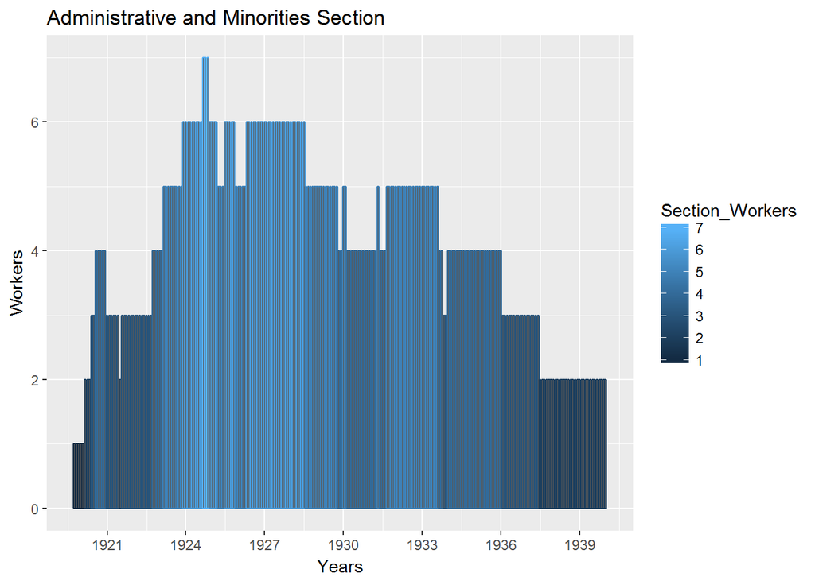

```r
source("employment_interval_function.R")

plot <- filter(large_section_worker,oname == levels(large_section_worker$oname)[1])

employment(plot, title1 = levels(large_section_worker$oname)[1])
```

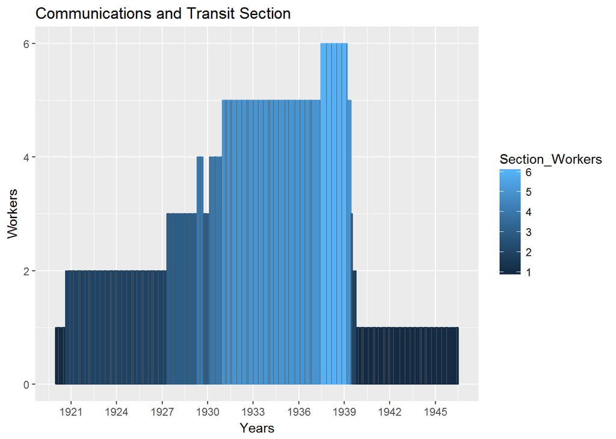

```r
plot <- filter(large_section_worker,oname == levels(large_section_worker$oname)[2])

employment(plot, title1 = levels(large_section_worker$oname)[2])
```

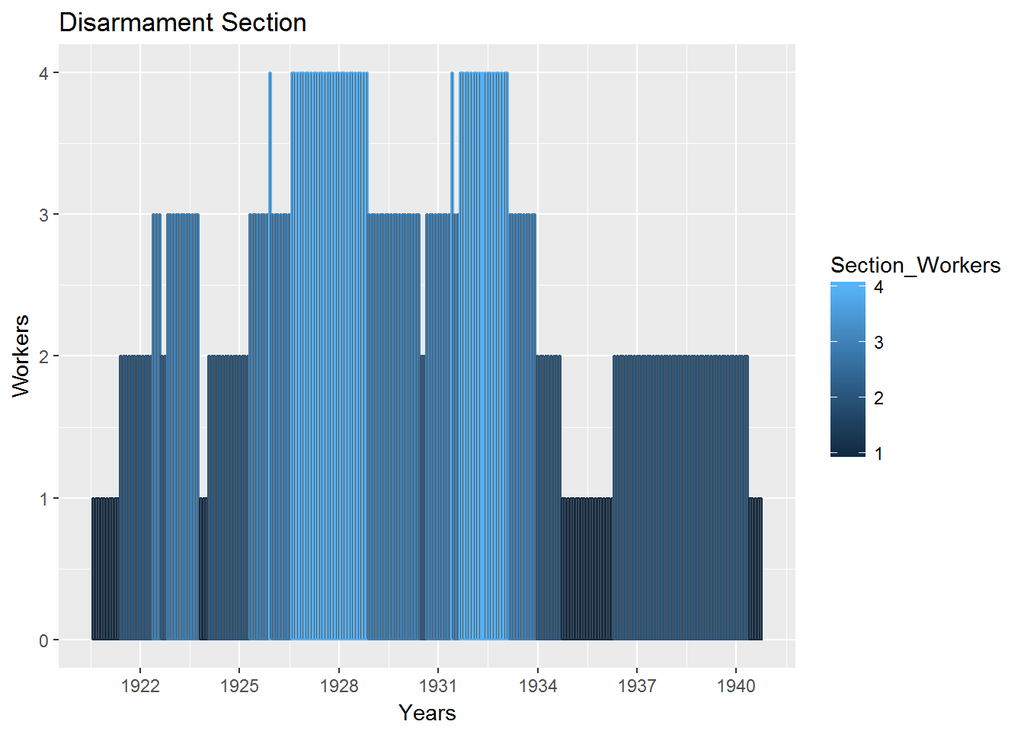

```r
plot <- filter(large_section_worker,oname == levels(large_section_worker$oname)[3])

employment(plot, title1 = levels(large_section_worker$oname)[3])
```

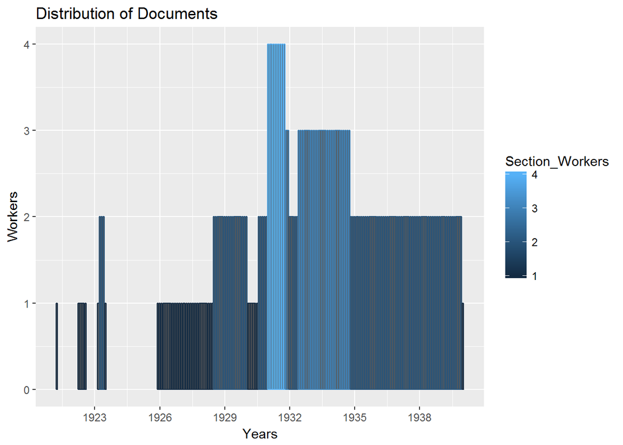

```r
plot <- filter(large_section_worker,oname == levels(large_section_worker$oname)[4])

employment(plot, title1 = levels(large_section_worker$oname)[4])
```

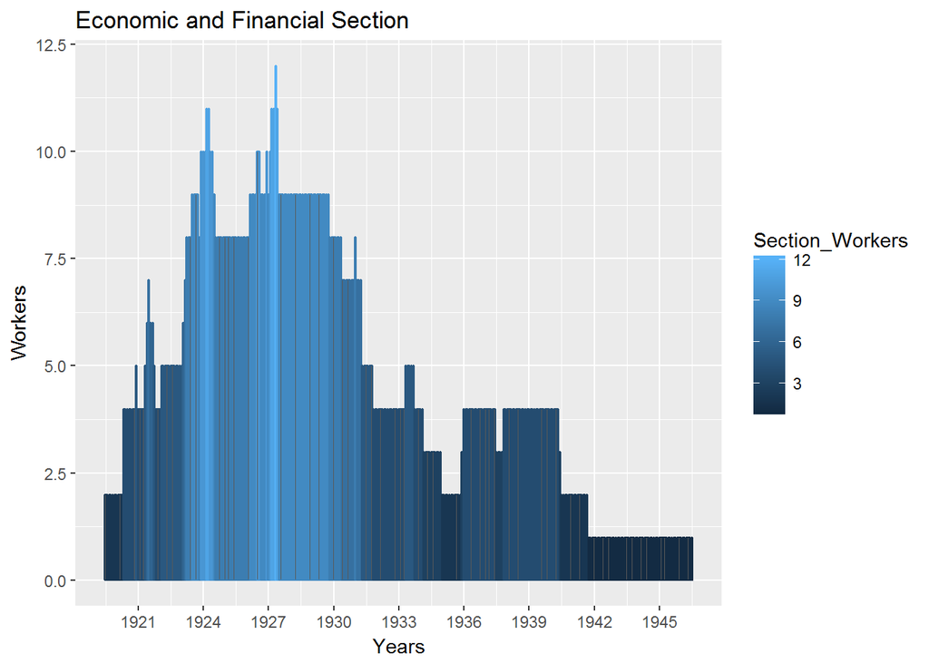

```r
plot <- filter(large_section_worker,oname == levels(large_section_worker$oname)[5])

employment(plot, title1 = levels(large_section_worker$oname)[5])
```

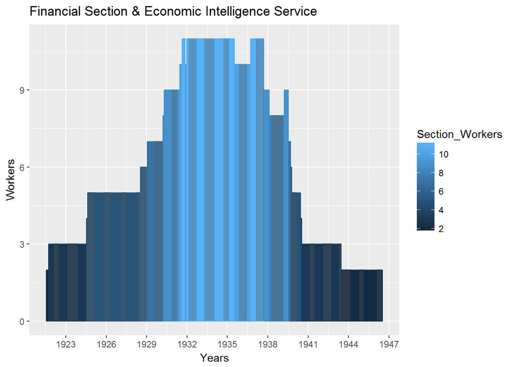

```r
plot <- filter(large_section_worker,oname == levels(large_section_worker$oname)[6])

employment(plot, title1 = levels(large_section_worker$oname)[6])
```

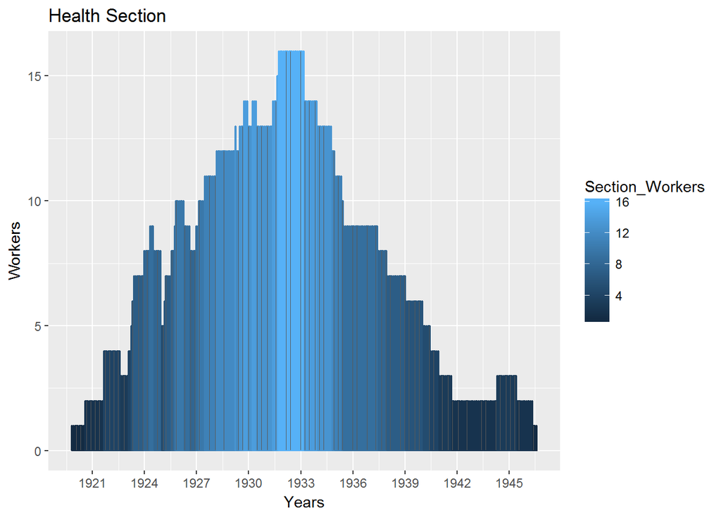

```r
plot <- filter(large_section_worker,oname == levels(large_section_worker$oname)[7])

employment(plot, title1 = levels(large_section_worker$oname)[7])
```

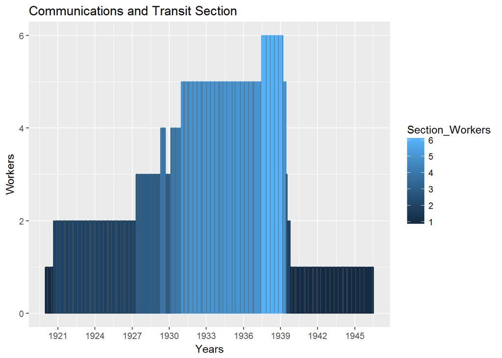

```r
plot <- filter(large_section_worker,oname == levels(large_section_worker$oname)[2])

employment(plot, title1 = levels(large_section_worker$oname)[2])
```

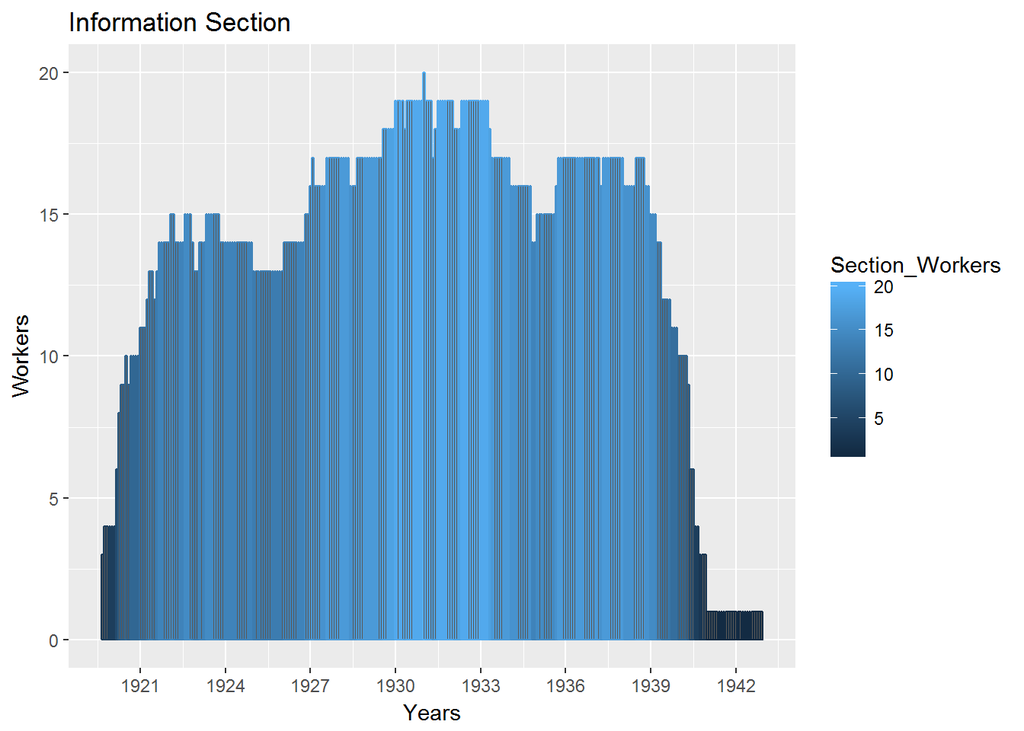

```r
plot <- filter(large_section_worker,oname == levels(large_section_worker$oname)[8])

employment(plot, title1 = levels(large_section_worker$oname)[8])
```

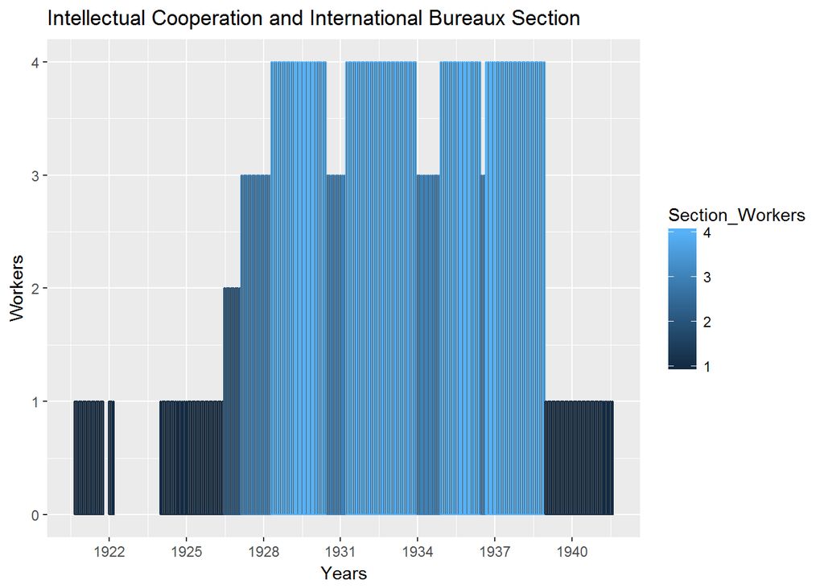

```r
plot <- filter(large_section_worker,oname == levels(large_section_worker$oname)[9])

employment(plot, title1 = levels(large_section_worker$oname)[9])
```

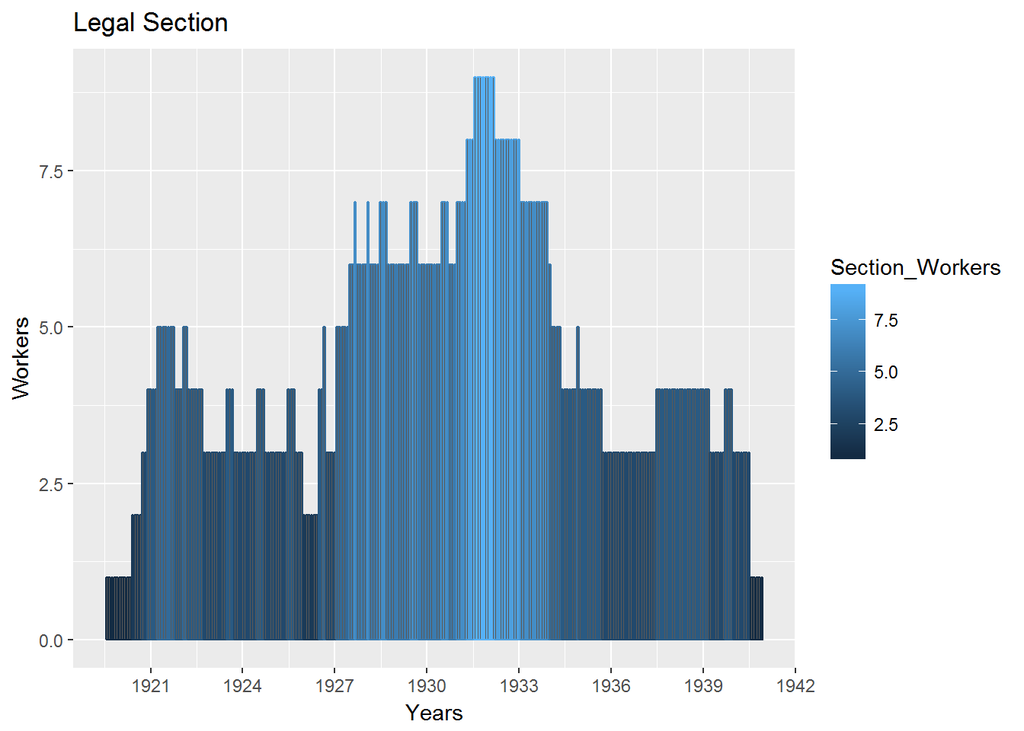

```r
plot <- filter(large_section_worker,oname == levels(large_section_worker$oname)[10])

employment(plot, title1 = levels(large_section_worker$oname)[10])
```

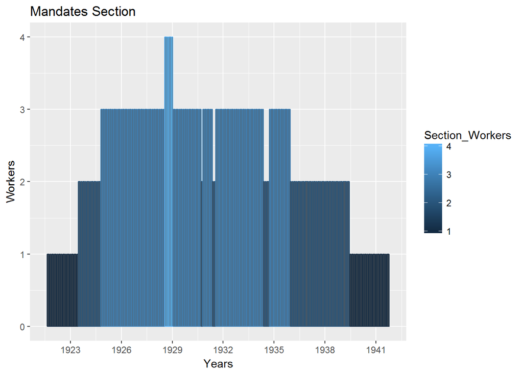

```r
plot <- filter(large_section_worker,oname == levels(large_section_worker$oname)[11])

employment(plot, title1 = levels(large_section_worker$oname)[11])
```

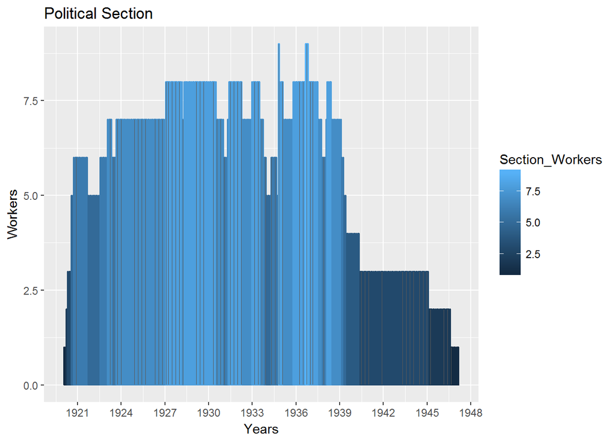

```r
plot <- filter(large_section_worker,oname == levels(large_section_worker$oname)[12])

employment(plot, title1 = levels(large_section_worker$oname)[12])
```

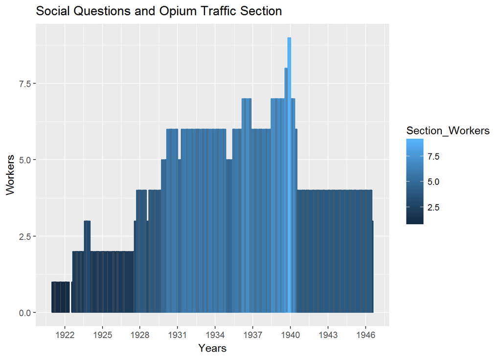

```r
plot <- filter(large_section_worker,oname == levels(large_section_worker$oname)[13])

employment(plot, title1 = levels(large_section_worker$oname)[13])
```